# Mario Kart World Records

12/9/2022

[figure not shown]

## Mario Kart 64 World Records

Two datasets were used in this project. Dataset **records** contains the information of world records of racing game Mario Kart 64 on Nintendo 64, and **drivers** dataset is the information of player.

For more detail of datasets, please visit [Mario Kart Dataset](https://github.com/rfordatascience/tidytuesday/blob/master/data/2021/2021-05-25/readme.md).

```
## # A tibble: 6 × 9
##   track         type  shortcut player system_played date       time_period  time
##   <chr>         <chr> <chr>    <chr>  <chr>         <date>     <chr>       <dbl>
## 1 Luigi Raceway Thre… No       Salam  NTSC          1997-02-15 2M 12.99S    133.
## 2 Luigi Raceway Thre… No       Booth  NTSC          1997-02-16 2M 9.99S     130.
## 3 Luigi Raceway Thre… No       Salam  NTSC          1997-02-16 2M 8.99S     129.
## 4 Luigi Raceway Thre… No       Salam  NTSC          1997-02-28 2M 6.99S     127.
## 5 Luigi Raceway Thre… No       Gregg… NTSC          1997-03-07 2M 4.51S     125.
## 6 Luigi Raceway Thre… No       Rocky… NTSC          1997-04-30 2M 2.89S     123.
## # ℹ 1 more variable: record_duration <dbl>
```

## Questions to investgate:

- What do the overall trends of the records?
- What are the current track records?
- How much has the time improved for each track?
- How much time were the longest held records beat by?

## What do the overall trends of the records?

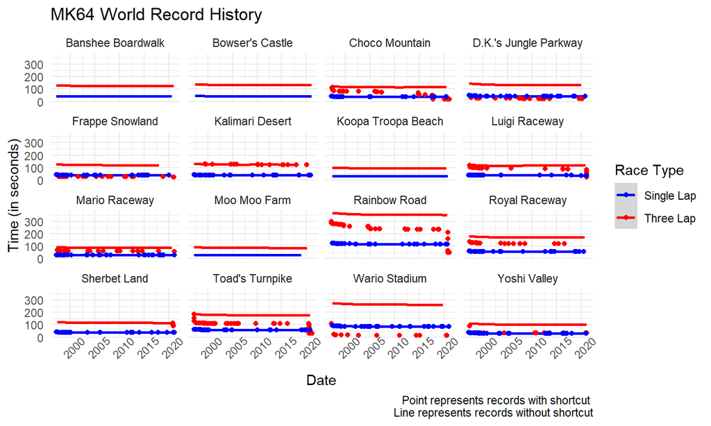

## What are the current track records for single lap?

MK64: Single Lap Track Records

|  | Race Type | System Played | Date | Time (sec) | Nationality |
| --- | --- | --- | --- | --- | --- |
| D.K.'s Jungle Parkway |  |  |  |  |  |
| Dan | Single Lap | PAL | 2020-10-26 | 42.04 | USA |
| Yoshi Valley |  |  |  |  |  |
| MR | Single Lap | PAL | 2018-01-18 | 31.25 | Germany |
| Dan | Single Lap | PAL | 2021-01-01 | 31.25 | USA |
| Banshee Boardwalk |  |  |  |  |  |
| Dan | Single Lap | PAL | 2020-06-11 | 40.78 | USA |
| MR | Single Lap | PAL | 2020-08-21 | 40.78 | Germany |
| Rainbow Road |  |  |  |  |  |
| MR | Single Lap | PAL | 2020-09-04 | 116.35 | Germany |

## What are the current track records for three laps?

MK64: Three Lap Track Records

|  | Race Type | System Played | Date | Time (sec) | Nationality |
| --- | --- | --- | --- | --- | --- |
| D.K.'s Jungle Parkway |  |  |  |  |  |
| abney317 | Three Lap | PAL | 2020-02-25 | 21.35 | USA |
| Yoshi Valley |  |  |  |  |  |
| abney317 | Three Lap | NTSC | 2020-12-03 | 33.35 | USA |
| VAJ | Three Lap | PAL | 2021-01-21 | 33.35 | Netherlands |
| Banshee Boardwalk |  |  |  |  |  |
| MR | Three Lap | PAL | 2021-01-15 | 124.09 | Germany |
| Rainbow Road |  |  |  |  |  |
| abney317 | Three Lap | NTSC | 2021-02-07 | 50.38 | USA |

## How much has the time improved for each track?

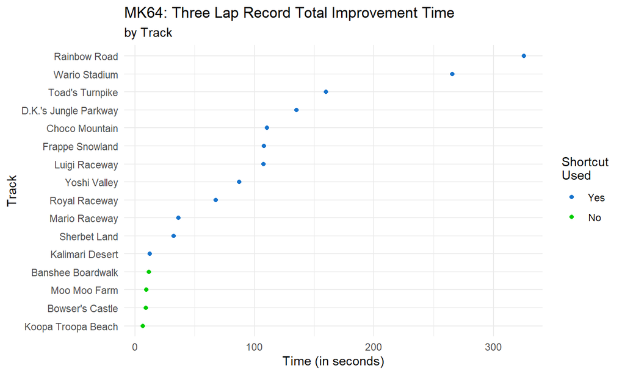

## Continued for single lap

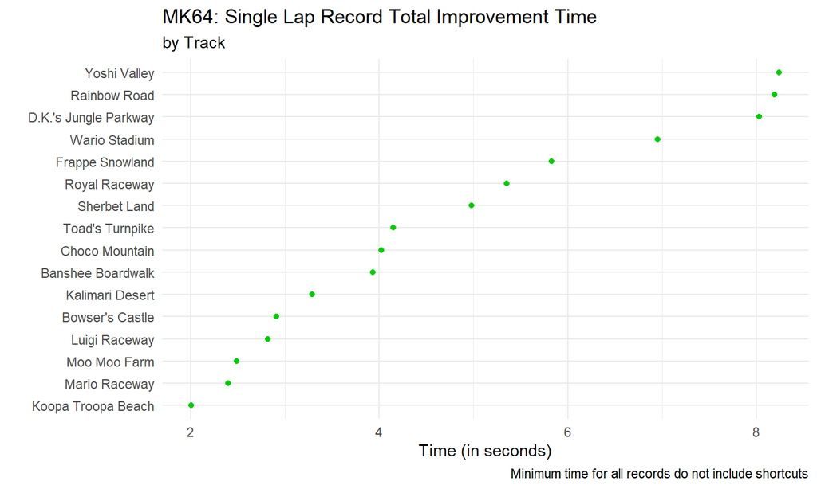

## How much time were the longest held records beat by for single lap without shortcut?

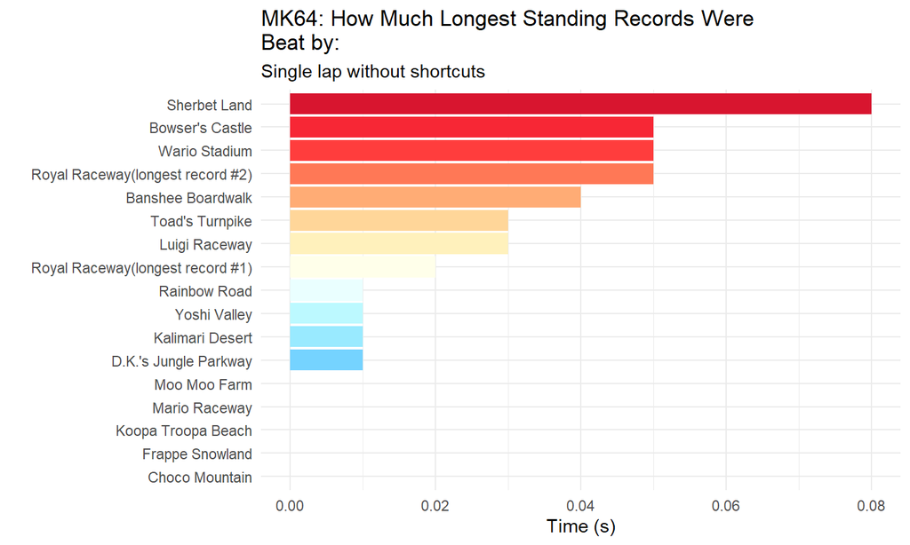

## How much time were the longest held records beat by for three laps without shortcut?

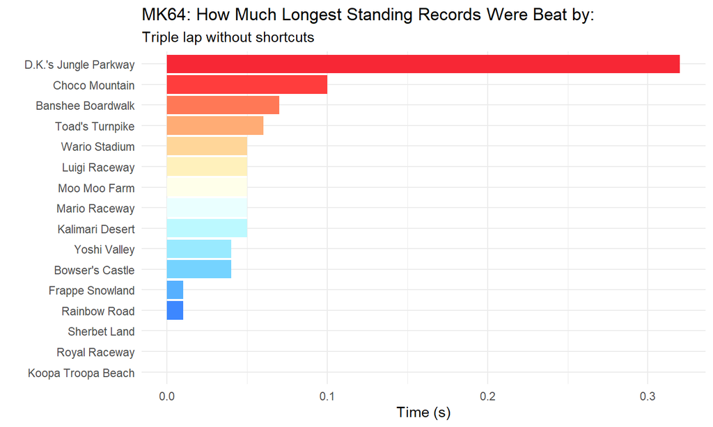

## How much time were the longest held records beat by for single lap with shortcut?

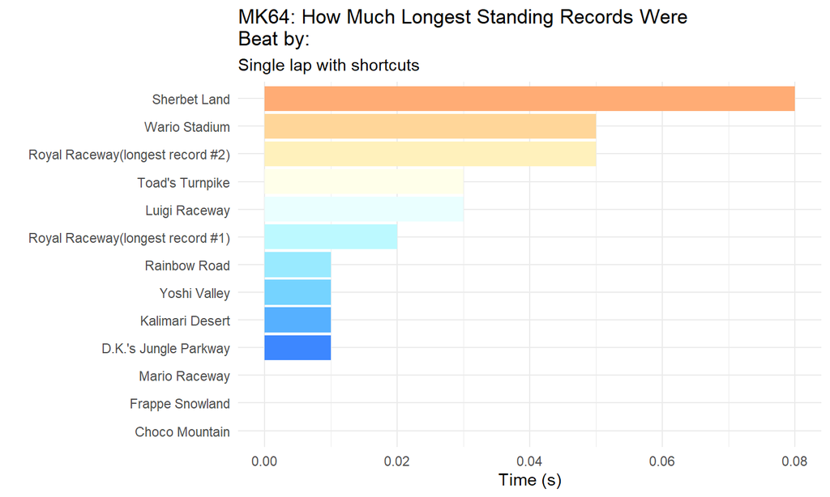

## How much time were the longest held records beat by for three laps with shortcut?

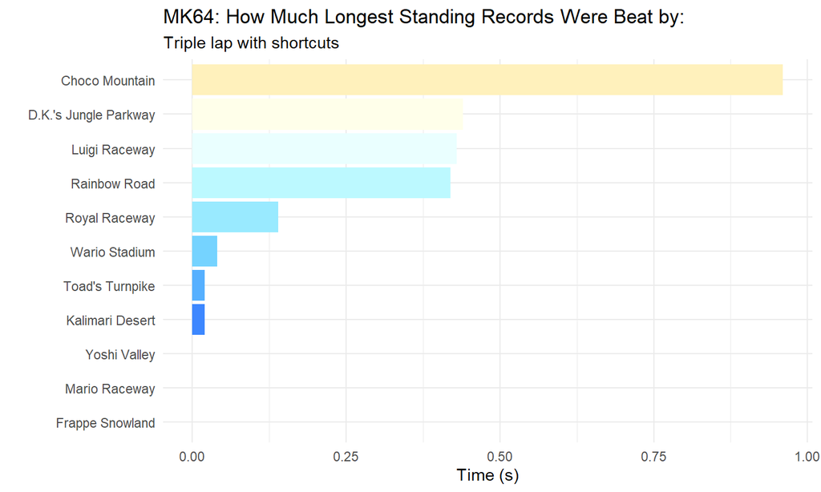

## Reference

- https://github.com/rfordatascience/tidytuesday/blob/master/data/2021/2021-05-25/readme.md
- https://www.mariokart64.com/mk64/
- https://mkwrs.com/
- https://mkwrs.com/mk64/